# Bayesian Forecast

```r
#Selecting necessary variables
data <- dplyr::select(data, c("YEAR", "COMPANY", "MARKET.CAP", "EARNINGS", "SALES", "CASH", "Name", "Sector", "Earnings_next_year"))

rand_data <- dplyr::select(data, c("YEAR", "COMPANY", "MARKET.CAP", "EARNINGS", "SALES", "CASH", "Name", "Sector", "Earnings_next_year"))

#Scaling Variables of Interest
data <- data %>%
  mutate(EARNINGS_Scaled = EARNINGS/1000000000,
         CASH_Scaled = CASH/1000000000,
         MARKET.CAP_Scaled = MARKET.CAP/1000000000,
         Earnings_next_year_Scaled = Earnings_next_year/1000000000,
         SALES_Scaled = SALES/1000000000)

#Adding Lagged Variables
data <- data %>%
  group_by(COMPANY) %>%
  mutate(EARNINGS_1_YEAR_AGO = lead(EARNINGS_Scaled, n = 1),
         EARNINGS_2_YEAR_AGO = lead(EARNINGS_Scaled, n = 2),
         EARNINGS_3_YEAR_AGO = lead(EARNINGS_Scaled, n = 3),
         EARNINGS_4_YEAR_AGO = lead(EARNINGS_Scaled, n = 4)) %>%
  mutate(SALES_1_YEAR_AGO = lead(SALES_Scaled, n = 1),
         SALES_2_YEAR_AGO = lead(SALES_Scaled, n = 2),
         SALES_3_YEAR_AGO = lead(SALES_Scaled, n = 3),
         SALES_4_YEAR_AGO = lead(SALES_Scaled, n = 4))


#Scaling Variables of Interest & Adding Lagged Variables to random subset of full data
rand_data <- rand_data %>%
  mutate(EARNINGS_Scaled = EARNINGS/1000000000,
         CASH_Scaled = CASH/1000000000,
         SALES_Scaled = SALES/1000000000,
         MARKET.CAP_Scaled = MARKET.CAP/1000000000,
         Earnings_next_year_Scaled = Earnings_next_year/1000000000,
         SALES_Scaled = SALES/1000000000,
         Earnings_1_years_ago = lead(EARNINGS_Scaled),
         Earnings_2_years_ago = lead(EARNINGS_Scaled, n =2),
         Earnings_3_years_ago = lead(EARNINGS_Scaled, n =3),
         Earnings_4_years_ago = lead(EARNINGS_Scaled, n =4)) %>%
  mutate(SALES_1_YEAR_AGO = lead(SALES_Scaled, n = 1),
         SALES_2_YEAR_AGO = lead(SALES_Scaled, n = 2),
         SALES_3_YEAR_AGO = lead(SALES_Scaled, n = 3),
         SALES_4_YEAR_AGO = lead(SALES_Scaled, n = 4))
```

### Bayesian Forecast SARIMA:

In our last model specification, we decided to use the bayesforcas package. In particular we are fitting a SARIMA model in Stan.

SARIMA stands for seasonal autoregressive integrated moving average. This is an extension of ARIMA and is therefore more robust as it is able to support seasonal data.

ARIMA is a method that combines both auto-regressive methods and moving averages- it is widely used on time series data in attempts to predict future values. There are four components that explain time series data, trend, seasonality, irregularity, and cyclic components.

Here are the parameters for an ARIMA model:

P - order of the AR term. This is the number of Y to be used as predictors. For example, if we are predicting 2021 earnings, how many previous years earnings are we going to use? Q- Order of the MA term. This is the number of lagged forecast errors. How many past forecast errors will we be using? D- the minimum differencing period. A stationary time series implies one that has properties that do not depend on the time at which the series is observed.

As mentioned above, SARIMA is able to support seasonal data. Below are the parameters for a SARIMA model that ARIMA does not have. P- Seasonal autoregressive order. A P=1 would make use of the first seasonally offset observation in the model, e.g. t-(m1) or t-12. A P=2, would use the last two seasonally offset observations t-(m1), t-(m2). D- Seasonal difference order. A D of 1 would calculate a first order seasonal difference and a Q=1 would use a first order error in the model (e.g. moving average). Q Seasonal moving average order. M- The number of time steps for a single seasonal period. M is a very important parameter as it influences the P, D, and Q parameters. For example, an m of 5 for yearly data suggests a 5-year seasonal cycle (in the context of business cycles.

```r
library(bayesforecast)
```

# Reason to use Bayesian forecast:

The reason that we are using Bayesian forecast is that using Bayesian forecast, we could see the prediction of the earnings not for next year but for 10 years in the future. Bayesian forecast was created based on seasonal order, trend or seasonality, which could predict the model fairly accurately.

After running the model, we then move on to predict the earnings of the future year for the companies. The companies we are going to predict will be Amazon (symbol: “AMZN”), American Airlines (symbol: “AAL”), and Koka Kola (symbol: “KO”).

```r
AMZN <- data %>%
  filter(COMPANY == 'AMZN') %>%
  dplyr::select(EARNINGS_Scaled) %>%
  arrange(EARNINGS_Scaled)
vector <- AMZN$EARNINGS_Scaled

myts <- ts(vector, start=c(1999), end=c(2021), frequency=1)

sf1 = stan_sarima(ts = myts,order = c(1,1,1),seasonal = c(1,1,1),
                  prior_mu0 = student(mu = 0,sd = 1,df = 7))
```

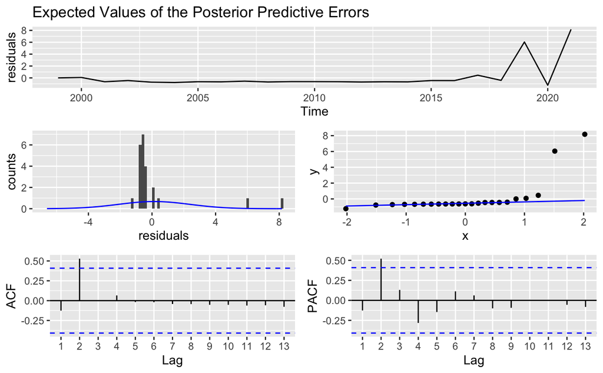

```r
check_residuals(sf1)
```

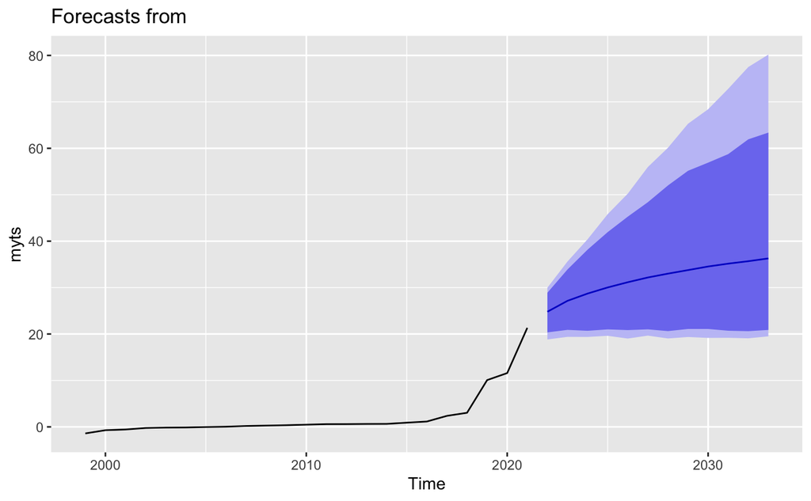

```r
autoplot(forecast(object = sf1,h = 12))
```

```r
AAL <- data %>%
  filter(COMPANY == 'AAL') %>%
  dplyr::select(EARNINGS_Scaled) %>%
  arrange(EARNINGS_Scaled)
vector <- AAL$EARNINGS_Scaled

myts <- ts(vector, start=c(1999), end=c(2021), frequency=1)

sf1 = stan_sarima(ts = myts,order = c(1,1,1),seasonal = c(1,1,1),
                  prior_mu0 = student(mu = 0,sd = 1,df = 7))
```

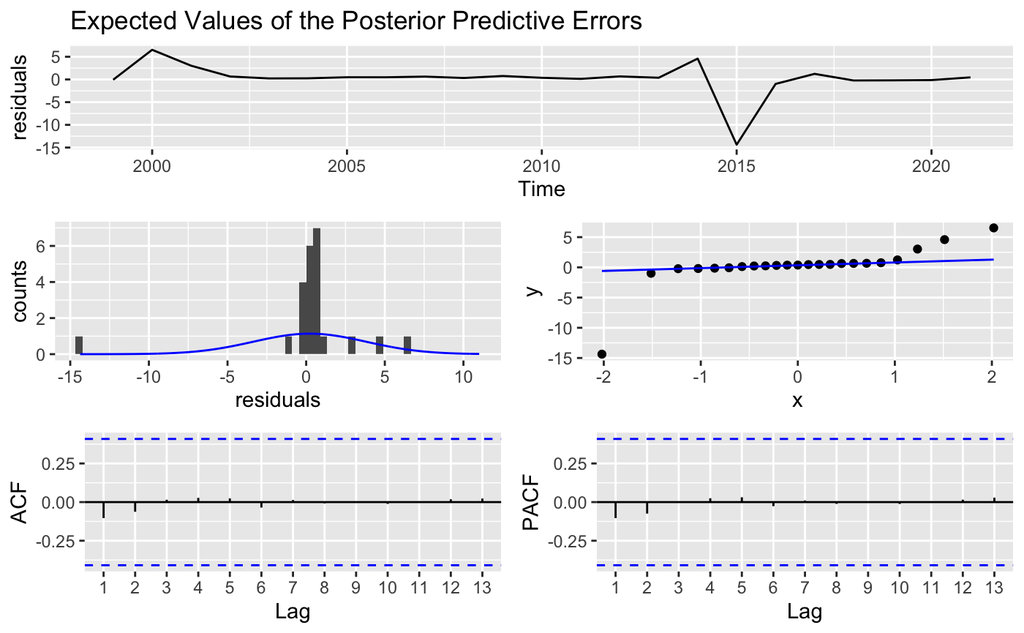

```r
check_residuals(sf1)
```

[figure not shown]

```r
autoplot(forecast(object = sf1,h = 12))
```

For American Airlines, we see a different story. As we can see from the graph, as airlines industry is an extremely cyclical field, the earnings fluctuate a lot. We could see that they fluctuate a lot during the previous years. With that in mind, the model predicts that American Airlines will not improve the much during the following years from 2021 to 2030 as predicting a cyclical company’s earnings could be a really difficult story. It did not show the similar pattern as Amazon.

```r
KO <- data %>%
  filter(COMPANY == 'KO') %>%
  dplyr::select(EARNINGS_Scaled) %>%
  arrange(EARNINGS_Scaled)
vector_KO <- KO$EARNINGS_Scaled

myts_KO <- ts(vector_KO, start=c(1999), end=c(2021), frequency=1)

sfKO = stan_sarima(ts = myts_KO,order = c(1,1,1),seasonal = c(1,1,1),
                  prior_mu0 = student(mu = 0,sd = 1,df = 7))
```

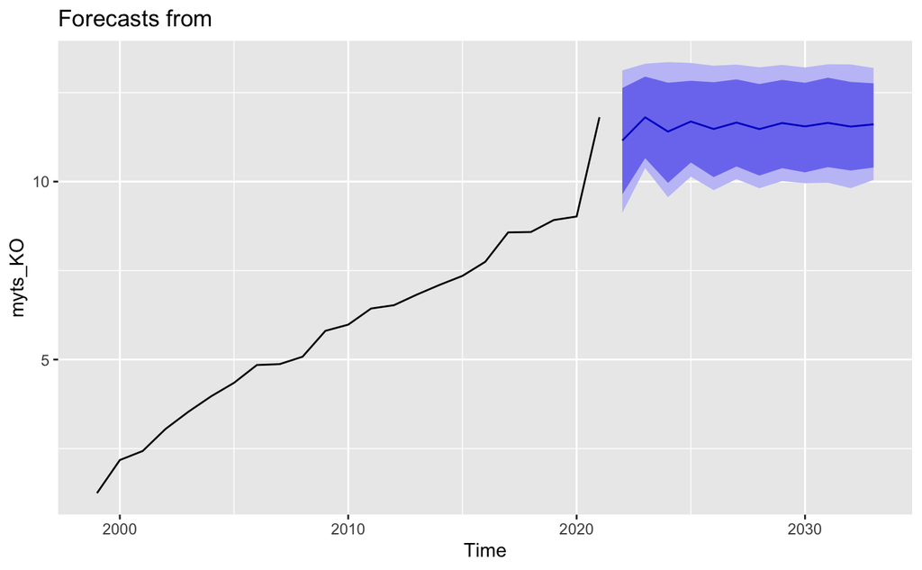

```r
# check_residuals(sf1)
autoplot(forecast(object = sfKO,h = 12))
```